title: “MPDW 2” author: “Butsainah Taqiah” date: “2023-09-12” output: html_document

#pemanggilan packages

```r
library("graphics")
library("TTR")
library("TSA")
library("rio")
library(dplyr)
library(TTR)
library(forecast)
library(lmtest)
library(orcutt)
library(HoRM)
library(readxl)
library(corrplot)
```

#input data

```r
datasol <- read_excel("C:/Users/taqia/Downloads/datarepsol.xlsx")
head(data)
```

[output not shown]

```r
str(data)
```

[output not shown]

# Peubah yang digunakan

```r
high <- datasol$High
low <- datasol$low
close <- datasol$close
volume <- datasol$volume
open <- datasol$open
```

# Mengubah data menjadi data deret waktu

```r
high.ts <- ts(high)
high.ts
```

```
## Time Series:
## Start = 1
## End = 103
## Frequency = 1
##   [1] 19.025 19.205 19.130 19.130 19.000 18.890 19.075 18.885 18.730 18.545
##  [11] 18.640 18.890 18.500 18.270 18.380 18.635 18.615 18.740 18.815 18.995
##  [21] 18.940 18.950 18.900 18.830 18.985 18.850 18.695 18.835 18.840 18.890
##  [31] 18.700 18.650 18.720 18.950 18.875 18.925 18.990 18.850 18.840 18.600
##  [41] 18.485 18.650 18.800 18.800 18.980 18.900 18.980 18.885 18.680 18.720
##  [51] 18.820 18.855 18.840 18.905 19.030 18.980 18.930 18.970 19.165 18.970
##  [61] 18.820 18.820 18.815 18.515 18.725 18.700 18.295 17.780 17.480 17.465
##  [71] 17.330 17.430 17.340 17.200 17.420 17.450 17.165 16.430 16.280 16.370
##  [81] 16.620 16.580 16.595 16.480 16.605 16.925 16.995 17.150 17.425 17.180
##  [91] 16.830 16.760 16.635 16.920 17.090 17.235 17.235 17.745 17.940 17.960
## [101] 17.970 17.900 18.050
```

```r
low.ts <- ts(low)
low.ts
```

```
## Time Series:
## Start = 1
## End = 103
## Frequency = 1
##   [1] 18.630 18.555 18.745 18.660 18.600 18.600 18.610 18.200 18.350 18.160
##  [11] 18.060 18.060 18.060 17.920 17.995 18.020 18.165 18.550 18.620 18.750
##  [21] 18.650 18.480 18.640 18.630 18.715 18.405 18.210 18.420 18.405 18.595
##  [31] 18.200 17.870 18.170 18.425 18.610 18.635 18.520 18.670 18.350 18.185
##  [41] 18.185 18.385 18.520 18.525 18.680 18.630 18.470 18.450 18.455 18.560
##  [51] 18.640 18.670 18.640 18.760 18.835 18.800 18.680 18.745 18.800 18.535
##  [61] 18.535 18.645 18.380 18.305 18.270 17.980 17.685 17.275 17.155 17.075
##  [71] 17.010 16.870 16.880 16.905 16.920 17.030 16.375 15.805 15.820 16.015
##  [81] 16.200 16.100 16.150 16.235 16.300 16.660 16.660 16.700 16.955 16.605
##  [91] 16.390 16.160 16.355 16.640 16.760 16.835 16.975 17.000 17.625 17.555
## [101] 17.660 17.700 17.695
```

```r
close.ts <- ts(close)
close.ts
```

```
## Time Series:
## Start = 1
## End = 103
## Frequency = 1
##   [1] 18.740 18.645 18.985 18.815 18.990 18.885 18.640 18.440 18.585 18.280
##  [11] 18.605 18.165 18.440 18.045 18.240 18.500 18.500 18.740 18.815 18.820
##  [21] 18.850 18.700 18.795 18.750 18.810 18.500 18.345 18.700 18.650 18.740
##  [31] 18.270 18.505 18.300 18.745 18.715 18.765 18.845 18.755 18.480 18.340
##  [41] 18.375 18.420 18.680 18.695 18.940 18.730 18.495 18.860 18.530 18.600
##  [51] 18.780 18.740 18.725 18.830 18.885 18.800 18.810 18.790 18.850 18.670
##  [61] 18.600 18.700 18.380 18.450 18.670 18.095 17.770 17.400 17.250 17.340
##  [71] 17.135 16.870 17.145 17.070 17.400 17.050 16.445 15.820 16.235 16.290
##  [81] 16.320 16.260 16.230 16.330 16.550 16.740 16.960 17.090 16.995 16.775
##  [91] 16.600 16.360 16.635 16.840 17.040 17.150 17.160 17.675 17.890 17.740
## [101] 17.900 17.800 17.760
```

```r
open.ts <- ts(open)
open.ts
```

```
## Time Series:
## Start = 1
## End = 103
## Frequency = 1
##   [1] 18.975 19.040 18.745 19.130 18.795 18.890 18.885 18.885 18.440 18.530
##  [11] 18.280 18.795 18.165 18.270 18.045 18.240 18.500 18.550 18.740 18.815
##  [21] 18.820 18.850 18.700 18.795 18.715 18.810 18.500 18.420 18.700 18.750
##  [31] 18.700 18.270 18.630 18.495 18.745 18.715 18.765 18.730 18.670 18.480
##  [41] 18.250 18.385 18.640 18.680 18.695 18.900 18.730 18.495 18.455 18.560
##  [51] 18.700 18.780 18.775 18.760 18.835 18.885 18.800 18.910 18.800 18.850
##  [61] 18.670 18.730 18.700 18.380 18.450 18.670 18.095 17.680 17.400 17.150
##  [71] 17.330 17.135 16.880 17.145 17.100 17.400 17.090 16.430 15.830 16.235
##  [81] 16.375 16.455 16.260 16.235 16.490 16.660 16.740 16.960 17.090 16.995
##  [91] 16.775 16.600 16.360 16.885 16.840 17.040 17.150 17.010 17.675 17.890
## [101] 17.740 17.900 17.845
```

```r
volume.ts <- ts(volume)
volume.ts
```

```
## Time Series:
## Start = 1
## End = 103
## Frequency = 1
##   [1]   9311950  11987550   4913002   6165696   6315277   6758293   8533584
##   [8]   6516565   6213554   6022900   6883514   7641821   6341627   6957834
##  [15]  10260543   6898626   4467224   5646882   7791860   5923057   6040577
##  [22]   8540227   7474722   6537266   6195547   6188342   8576749   5474443
##  [29]   5236797   3698346   6057088   8506736   6150483   9317415   7149099
##  [36]   4807918  12760773   4366914   4929433  45473232   5775687   5851519
##  [43]   5273551  54956636  20543620  12477312  45635724 102653568   4777502
##  [50] 144851376   3228856  49502276   2987900  13665681  12792600  19931384
##  [57]  12346950  11372020   9582063   8811927  13937247   5790062  11317970
##  [64]   4284633   7563380  10545105   8463417  12331230   8822119   9278662
##  [71]   9716475  10002854   8978480   8934448   5918497   7808159  14672580
##  [78]  15275780  10880450   9101998   8510333   6789545   5208062   2834031
##  [85]   5105529   8238494   7488921  10441878  10108298   7035554   6946559
##  [92]   9649660   7683155   5519167   7928997   5986828   8067518  10721519
##  [99]   7166508   5921115   9517157   4249008   7085363
```

#eksplorasi data

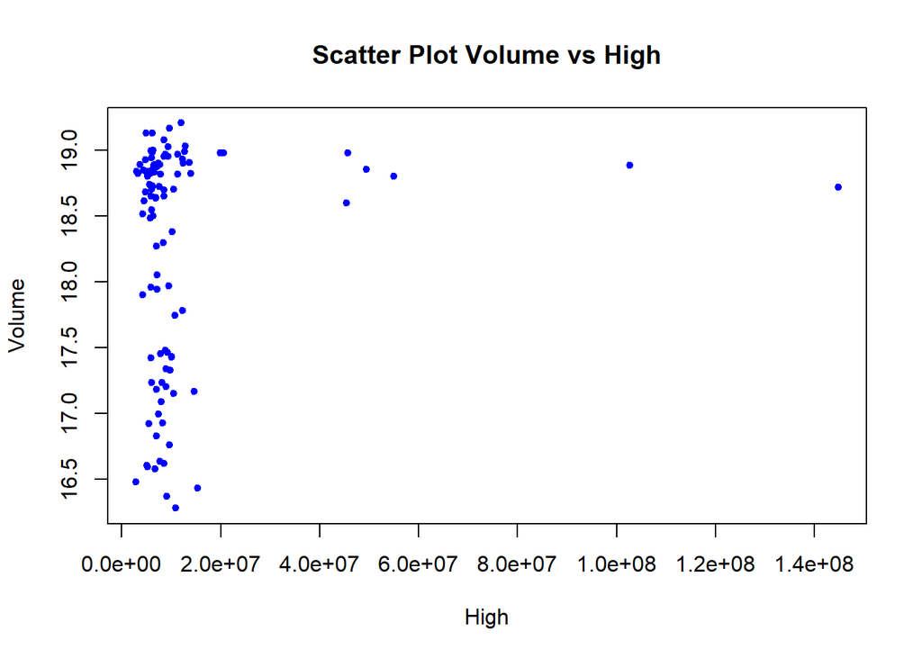

```r
# scatter plot Volume vs high
plot(volume,high, pch = 20, col = "blue",
     main = "Scatter Plot Volume vs High",
     xlab = "High",
     ylab = "Volume")
```

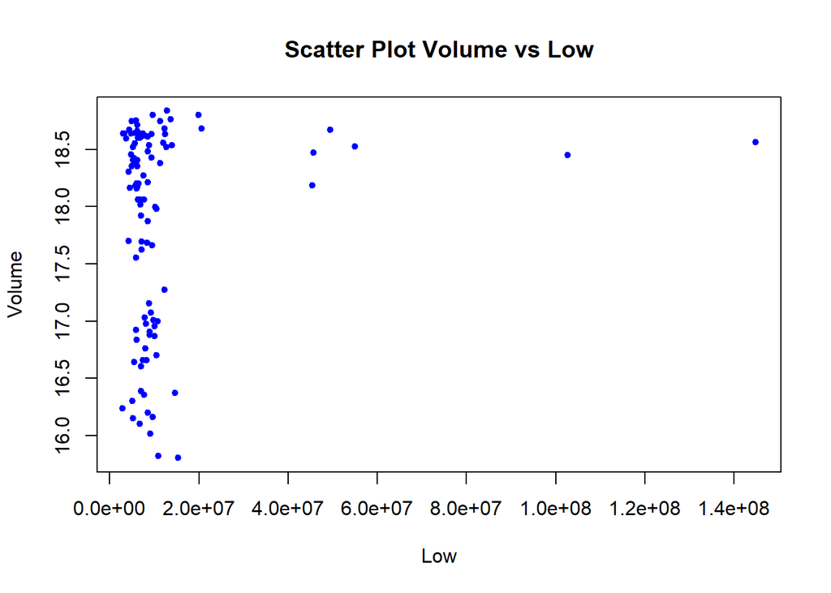

```r
# scatter plot Volume vs low
plot(volume,low, pch = 20, col = "blue",
     main = "Scatter Plot Volume vs Low",
     xlab = "Low",
     ylab = "Volume")
```

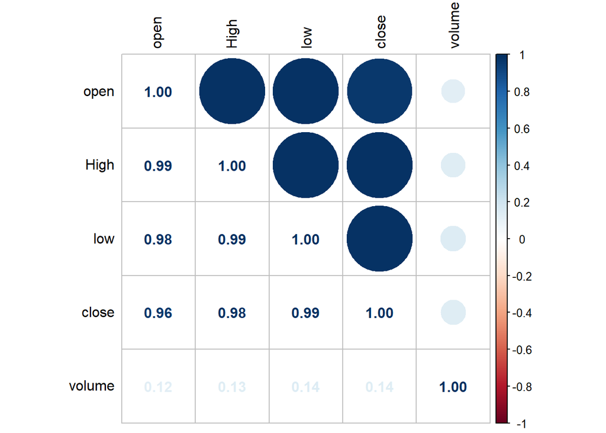

```r
# Cek Korelasi
data<-datasol[,-6]
matriks <- cor(data)
corrplot.mixed(matriks, upper = 'circle', lower = 'number', order = "original",
               tl.col="black", tl.pos = "lt",diag = 'l',
               number.digits=2, number.cex=1)
```

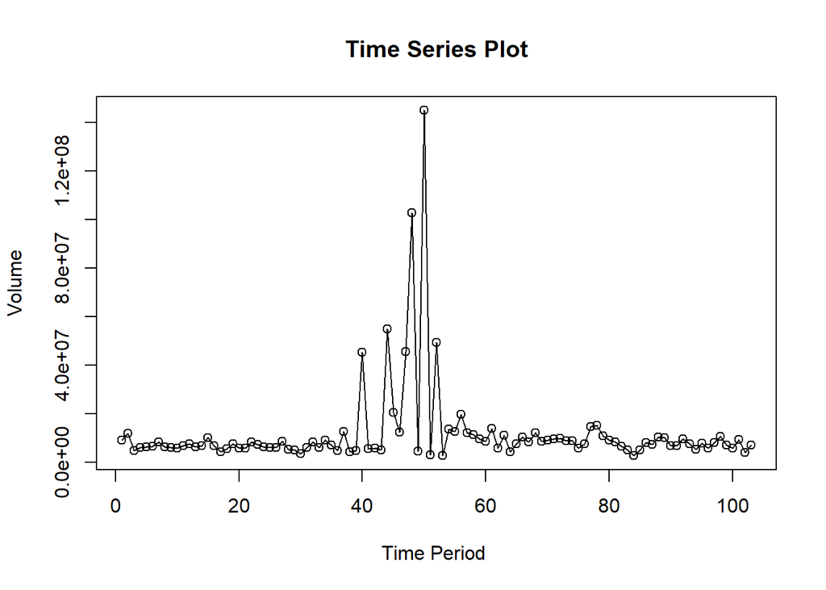

```r
# Plot time series
## Volume
ts.plot(volume.ts, xlab="Time Period ", ylab="Volume",
        main = "Time Series Plot")
points(volume.ts)
```

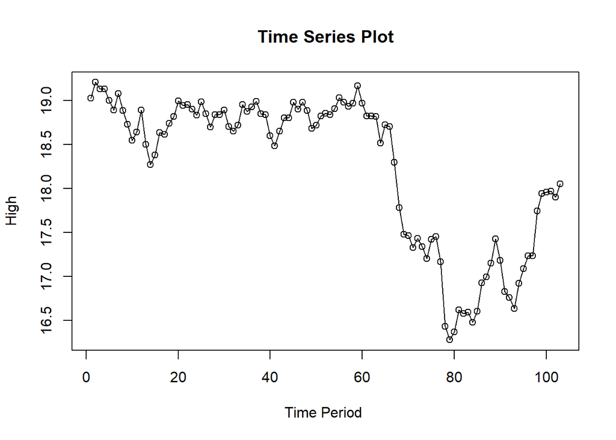

```r
## High
ts.plot(high.ts, xlab="Time Period ", ylab="High",
        main = "Time Series Plot")
points(high.ts)
```

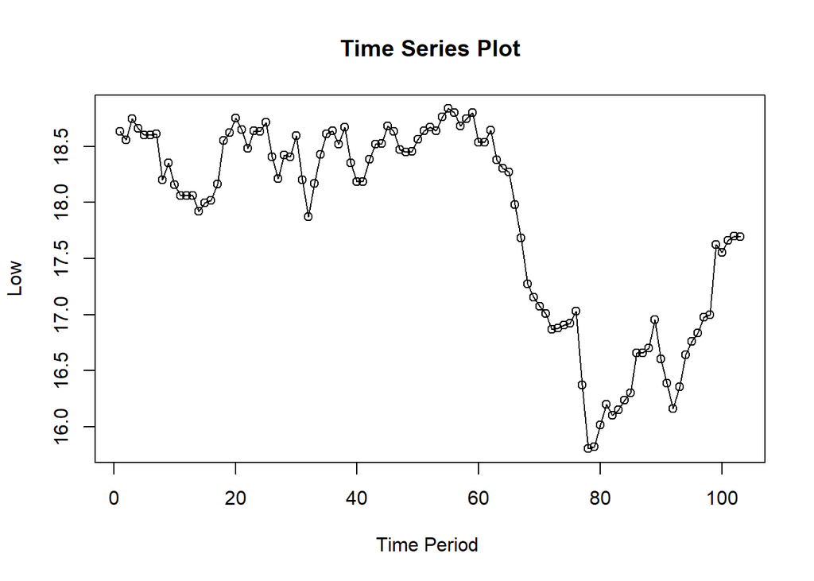

```r
## Low
ts.plot(low.ts, xlab="Time Period ", ylab="Low",
        main = "Time Series Plot")
points(low.ts)
```

# Pembuatan regresi time series

```r
#membuat model awal
model1 <- lm(volume~high+low)
summary(model1)
```

```
##
## Call:
## lm(formula = volume ~ high + low)
##
## Residuals:
##       Min        1Q    Median        3Q       Max
## -12230687  -7370653  -3311037   -433906 129566290
##
## Coefficients:
##              Estimate Std. Error t value Pr(>|t|)
## (Intercept) -31854902   39477852  -0.807    0.422
## high         -6860354   12380924  -0.554    0.581
## low           9459365   11917452   0.794    0.429
##
## Residual standard error: 18180000 on 100 degrees of freedom
## Multiple R-squared:  0.02392,    Adjusted R-squared:  0.004403
## F-statistic: 1.226 on 2 and 100 DF,  p-value: 0.298
```

#plot asumsi

```r
#sisaan dan fitted value
sisaan1<- residuals(model1)
fitValue1<- predict(model1)
```

#Diagnostik dengan eksploratif

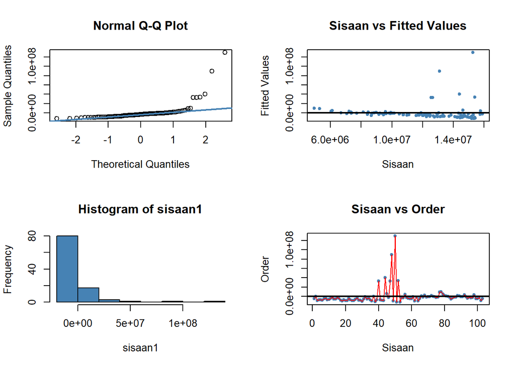

```r
par(mfrow = c(2,2))
qqnorm(sisaan1)
qqline(sisaan1, col = "steelblue", lwd = 2)
plot(fitValue1, sisaan1, col = "steelblue", pch = 20, xlab = "Sisaan", ylab = "Fitted Values", main = "Sisaan vs Fitted Values")
abline(a = 0, b = 0, lwd = 2)
hist(sisaan1, col = "steelblue")
plot(seq(1,103,1), sisaan1, col = "steelblue", pch = 20, xlab = "Sisaan", ylab = "Order", main = "Sisaan vs Order")
lines(seq(1,103,1), sisaan1, col = "red")
abline(a = 0, b = 0, lwd = 2)
```

Normal Q-Q Plot di atas menunjukkan bahwa sisaan cenderung tidak menyebar normal, dan histogram dari sisaan menunjukkan demikian. Selanjutnya, Plot Sisaan vs *Fitted Value* dan Plot Sisaan vs *Order* menunjukkan adanya pola pada sisaan. Untuk lebih lanjut akan digunakan uji formal melihat normalitas sisaan dan plot ACF dan PACF untuk melihat apakah ada autokorelasi atau tidak.

#uji formal normalitas

```r
#H0: sisaan mengikuti sebaran normal
#H1: sisaan tidak mengikuti sebaran normal
ks.test(sisaan1, "pnorm", mean=mean(sisaan1), sd=sd(sisaan1))
```

```
##
##  Asymptotic one-sample Kolmogorov-Smirnov test
##
## data:  sisaan1
## D = 0.32028, p-value = 1.33e-09
## alternative hypothesis: two-sided
```

Berdasarkan uji formal Kolmogorov-Smirnov didapatkan nilai *p-value* < $\alpha$ (5%). Artinya, belum cukup bukti untuk menyatakan sisaan berdistribusi normal. maka dari itu dilakukan transformasi.

## Transformasi karna data tidak normal (1/x dan 1/y)

```r
Volumetrans <- 1/(volume)
hightrans <- 1/(high)
lowtrans <- 1/(low)
```